# 5206HW4.CM3700

Chi.Ma,cm3700

11/8/2017

```r
setwd("~/Desktop/5206/HW")
debt <- read.csv("debt.csv", as.is = TRUE)
dim(debt)
```

```
## [1] 1171    4
```

```r
head(debt)
```

```
##     Country Year    growth     ratio
## 1 Australia 1946 -3.557951 190.41908
## 2 Australia 1947  2.459475 177.32137
## 3 Australia 1948  6.437534 148.92981
## 4 Australia 1949  6.611994 125.82870
## 5 Australia 1950  6.920201 109.80940
## 6 Australia 1951  4.272612  87.09448
```

```r
library(plyr)
```

# Part 1

Calculate the average GDP growth rate for each country (averaging over years). This is a classic split/apply/combine problem, and you will use daply() to solve it.

1. Begin by writing a function, mean.growth(), that takes a data frame as its argument and returns the mean of the ‘growth‘ column of that data frame.

```r
mean.growth<-function(country.debt){
  return(mean(country.debt$growth))
}
```

2. Use daply() to apply mean.growth() to each country in debt. Don’t use some- thing like mean(debt$growth[debt$Country==“Australia”]), except to check your work. You should not need to use a loop to do this. (The average growth rates for Australia and the Netherlands should be 3.72 and 3.03. Print these values.) Report the average GDP growth rates clearly.

```r
country.growth<-daply(debt,.(Country),mean.growth)
signif(country.growth,3)
```

```
##   Australia     Austria     Belgium      Canada     Denmark     Finland
##        3.72        4.44        3.18        3.65        2.66        3.57
##      France     Germany      Greece     Ireland       Italy       Japan
##        3.78        3.31        2.93        3.93        3.25        4.45
## Netherlands New Zealand      Norway    Portugal       Spain      Sweden
##        3.03        3.07        3.83        4.00        3.20        3.07
##          UK          US
##        2.41        3.00
```

# Part 2

2. Using the same instructions as problem 1, calculate the average GDP growth rate for each year (now averaging over countries). (The average growth rates for 1972 and 1989 should be 5.63 and 3.19, respectively. Print these values in your output.) Make a plot of the growth rates (y-axis) versus the year (x-axis). Make sure the axes are labeled appropriately.

```r
year.growth<-daply(debt,.(Year),mean.growth)
signif(year.growth,3)
```

```
##   1946   1947   1948   1949   1950   1951   1952   1953   1954   1955
##  2.620  5.410  5.560  4.740  6.320  4.920  3.400  4.090  4.880  5.140
##   1956   1957   1958   1959   1960   1961   1962   1963   1964   1965
##  4.230  3.910  2.240  5.310  5.860  4.890  4.960  4.830  6.370  4.720
##   1966   1967   1968   1969   1970   1971   1972   1973   1974   1975
##  4.310  4.040  5.270  6.250  4.610  4.070  5.630  5.970  1.990  0.830
##   1976   1977   1978   1979   1980   1981   1982   1983   1984   1985
##  4.170  2.630  3.320  4.190  1.870  0.992  0.876  2.040  4.060  3.520
##   1986   1987   1988   1989   1990   1991   1992   1993   1994   1995
##  2.890  2.450  2.920  3.190  2.570  1.330  1.590  1.020  3.860  3.630
##   1996   1997   1998   1999   2000   2001   2002   2003   2004   2005
##  3.390  4.070  3.090  3.480  4.060  2.040  1.970  1.870  3.290  2.620
##   2006   2007   2008   2009
##  3.140  3.140  0.798 -3.370
```

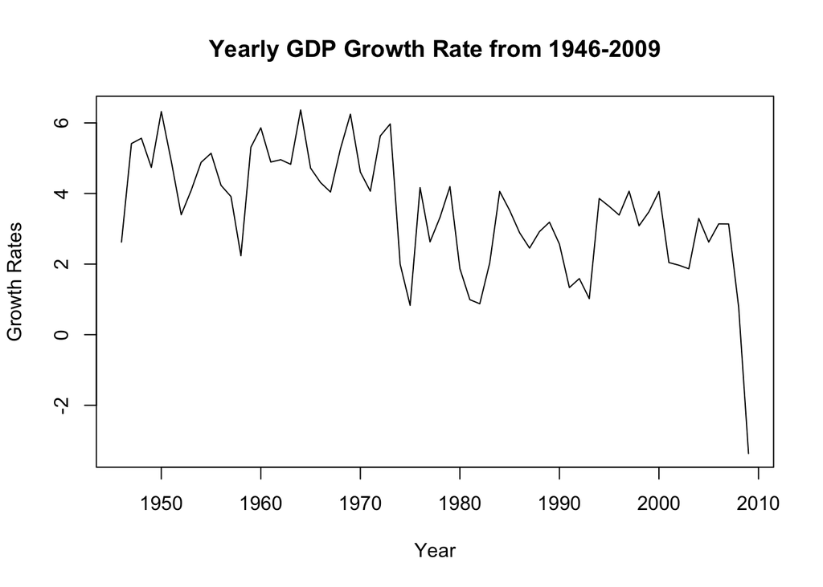

```r
years=1946:2009
plot(x=years,y=year.growth, type="l" , xlab ="Year",ylab = "Growth Rates", main = "Yearly GDP Growth Rate from 1946-2009")
```

#Part 3 3. The function cor(x,y) calculates the correlation coefficient between two vectors x and y. a. Calculate the correlation coefficient between GDP growth and the debt ratio over the whole data set (all countries, all years). Your answer should be −0.1995.

```r
signif(cor(debt$growth,debt$ratio),4)
```

```
## [1] -0.1995
```

2. Compute the correlation coefficient separately for each country, and plot a his- togram of these coefficients (with 10 breaks). The mean of these correlations should be −0.1778. Do not use a loop. (Hint: consider writing a function and then making it an argument to daply()).

```r
debt.pxy<-function(country.gdp){
  cor(country.gdp$growth,country.gdp$ratio)
}

country.pxy<-daply(debt,.(Country),debt.pxy)
signif(country.pxy,3)
```

```
##   Australia     Austria     Belgium      Canada     Denmark     Finland
##    0.025200   -0.253000   -0.192000    0.075000   -0.168000    0.000581
##      France     Germany      Greece     Ireland       Italy       Japan
##   -0.502000   -0.576000   -0.093500   -0.140000   -0.645000   -0.702000
## Netherlands New Zealand      Norway    Portugal       Spain      Sweden
##   -0.199000    0.161000    0.563000   -0.352000    0.081400   -0.161000
##          UK          US
##   -0.137000   -0.341000
```

```r
mean(country.pxy)
```

```
## [1] -0.177822
```

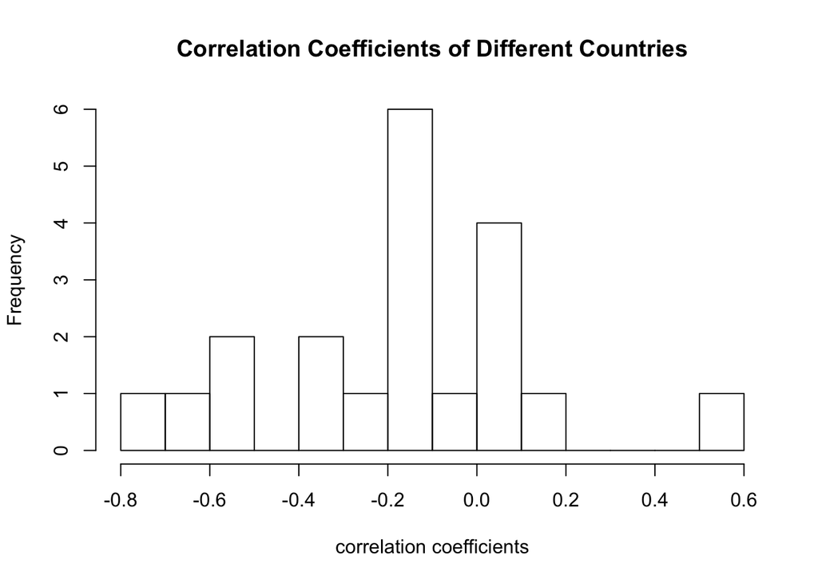

```r
hist(country.pxy, breaks  = 10, xlab = "correlation coefficients", main = "Correlation Coefficients of Different Countries")
```

c. Calculate the correlation coefficient separately for each year, and plot a histogram of these coefficients. The mean of these correlations should be −0.1906.

```r
year.pxy<-daply(debt,.(Year),debt.pxy)
signif(year.pxy,3)
```

```
##     1946     1947     1948     1949     1950     1951     1952     1953
## -0.62000 -0.27400 -0.34000 -0.20000  0.03980 -0.41600 -0.27700 -0.20500
##     1954     1955     1956     1957     1958     1959     1960     1961
## -0.27500 -0.22700 -0.45800 -0.75500 -0.45400 -0.28500 -0.50400 -0.53900
##     1962     1963     1964     1965     1966     1967     1968     1969
## -0.38300  0.12800 -0.36100 -0.31100 -0.31100 -0.27800 -0.18100 -0.25000
##     1970     1971     1972     1973     1974     1975     1976     1977
## -0.51200  0.00872 -0.19600  0.11400  0.26000  0.27100 -0.17100  0.16400
##     1978     1979     1980     1981     1982     1983     1984     1985
##  0.43100 -0.42900 -0.12700  0.03040  0.23900 -0.36200 -0.15600 -0.44900
##     1986     1987     1988     1989     1990     1991     1992     1993
## -0.35800 -0.06890  0.07970  0.06640  0.15600  0.20200 -0.00222 -0.37200
##     1994     1995     1996     1997     1998     1999     2000     2001
## -0.22400  0.05190 -0.35700 -0.11100 -0.26500 -0.25800 -0.13400 -0.23800
##     2002     2003     2004     2005     2006     2007     2008     2009
## -0.34900 -0.06790 -0.17100 -0.31400 -0.19600 -0.34400 -0.09450 -0.20500
```

```r
mean(year.pxy)
```

```
## [1] -0.1905526
```

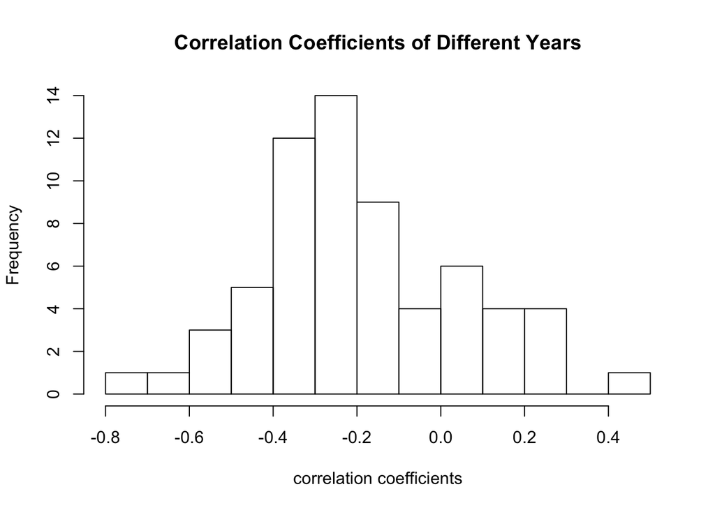

```r
hist(year.pxy, breaks  = 10, xlab = "correlation coefficients", main = "Correlation Coefficients of Different Years")
```

d. Are there any countries or years where the correlation goes against the general trend?

```r
#Country: The graph looks like general normal distribution, counldn't find a country that is deviate far from others, all correlations are in the 3 std range of the group mean.
#Years: The graph is in a nice shape, it seems every country is in general range.
```

# Part 4

4. Fit a linear model of overall growth on the debt ratio, using lm(). Report the intercept and slope. Make a scatter-plot of overall GDP growth (vertical) against the overall debt ratio (horizontal). Add a line to your scatterplot showing the fitted regression line.

```r
model_debt<-lm(debt$growth~debt$ratio)
model_debt$coefficients
```

```
## (Intercept)  debt$ratio
##  4.27929049 -0.01835518
```

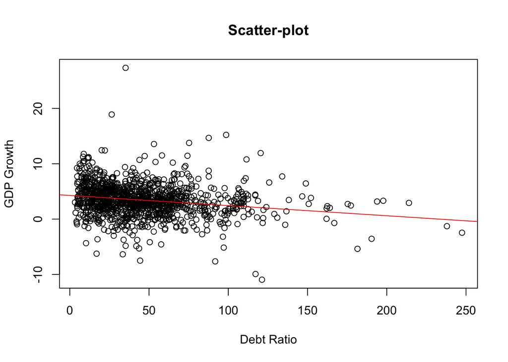

```r
plot(x=debt$ratio,y=debt$growth, xlab = "Debt Ratio", ylab = "GDP Growth", main = "Scatter-plot")
abline(lm(growth~ratio, data = debt), col = "red")
```

5. There should be four countries with a correlation smaller than -0.5. Separately, plot GDP growth versus debt ratio from each of these four countries and put the country names in the titles. This should be four plots. Call par(mfrow=c(2,2)) before plotting so all four plots will appear in the same figure. (Think about what this shows: individual relationships at the country level are sometimes concealed or ”smudged out” when data is aggregated over all groups (countries). This conveys the importance of careful analysis at a more granular group level, when such groupings are available!)

```r
which(country.pxy<=-0.5)
```

```
##  France Germany   Italy   Japan
##       7       8      11      12
```

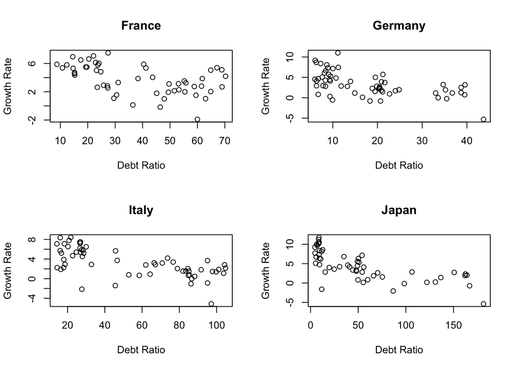

```r
fd<-subset(debt,debt$Country=="France")
gd<-subset(debt,debt$Country=="Germany")
id<-subset(debt,debt$Country=="Italy")
jd<-subset(debt,debt$Country=="Japan")

four.country<-rbind(fd,gd,id,jd)

plot.funct<-function(mydf){
  plot(x=mydf$ratio,y=mydf$growth,xlab = "Debt Ratio", ylab = "Growth Rate",main = mydf$Country[1])
}

par(mfrow=c(2,2))
d_ply(four.country,.(Country),plot.funct)
```

6. Some economists claim that high levels of government debt cause slower growth. Other economists claim that low economic growth leads to higher levels of government debt. The data file, as given, lets us relate this year’s debt to this year’s growth rate; to check these claims, we need to relate current debt to future growth. a. Create a new data frame which just contains the rows of debt for France, but contains all those rows. It should have 54 rows and 4 columns (print the dimen- sions of your data frame). Note that some years are missing from the middle of this data set.

```r
dim(fd)
```

```
## [1] 54  4
```

2. Create a new column in your data frame for France, next.growth, which gives next year’s growth if the next year is in the data frame, or NA if the next year is missing. (next.growth for 1971 should be (rounded) 5.886, but for 1972 it should be NA. Print these two values.)

```r
fd$next.growth<-NA
for (i in 1:(nrow(fd)-1)) {
  if (fd$Year[i]+1 == fd$Year[i+1]){#sum(debt_France$Year == debt_France$Year[i]+1) == 1
    fd$next.growth[i] =signif(fd$growth[i+1],4)
  }
  else{
    fd$next.growth[i] = NA
  }
}

fd$next.growth[which(fd$Year == 1971)]
```

```
## [1] 5.886
```

```r
fd$next.growth[which(fd$Year == 1972)]
```

```
## [1] NA
```

7. Add a next.growth column, as in the previous question, to the whole of the debt data frame. Make sure that you do not accidentally put the first growth value for one country as the next.growth value for another. (The next.growth for France in 2009 should be NA, not 9.167. Print this value.) Hints: Write a function to encapsulate what you did in the previous question, and apply it using ddply().

```r
next.funct<-function(df){
  df$next.growth<- NA
  for (i in 1:(nrow(df)-1)){
    if (df$Year[i]+1 == df$Year[i+1]){
      df$next.growth[i] = signif(df$growth[i+1])
    }
    else{
      df$next.growth[i] = NA
    }
  }
  return(df)
}
debt<-ddply(debt,.(Country),next.funct)
debt[which(debt$Country=="France"&debt$Year==2009),]$next.growth
```

```
## [1] NA
```

8. Make a scatter-plot of next year’s GDP growth against this year’s debt ratio. Linearly regress next year’s growth rate on the current year’s debt ratio, and add the line to the plot. Report the intercept and slope to reasonable precision. How do they compare to the regression of the current year’s growth on the current year’s debt ratio?

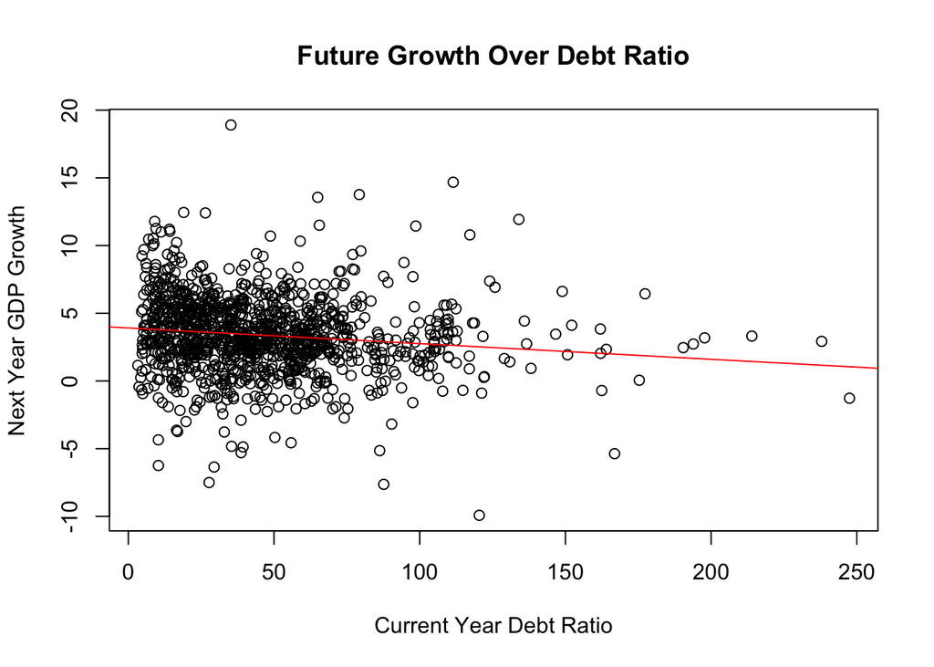

```r
plot(x=debt$ratio,y=debt$next.growth, xlab = "Current Year Debt Ratio",ylab = "Next Year GDP Growth",main ="Future Growth Over Debt Ratio" )
abline(lm(next.growth~ratio,data = debt),col="red")
```

```r
model_8<-lm(next.growth~ratio,data = debt)
signif(model_8$coefficients,3)
```

```
## (Intercept)       ratio
##      3.9200     -0.0116
```

```r
summary(model_8)
```

```
##
## Call:
## lm(formula = next.growth ~ ratio, data = debt)
##
## Residuals:
##      Min       1Q   Median       3Q      Max
## -12.4488  -1.4567  -0.0374   1.6331  15.3863
##
## Coefficients:
##              Estimate Std. Error t value Pr(>|t|)
## (Intercept)  3.924721   0.143852  27.283  < 2e-16 ***
## ratio       -0.011608   0.002555  -4.544 6.11e-06 ***
## ---
## Signif. codes:  0 '***' 0.001 '**' 0.01 '*' 0.05 '.' 0.1 ' ' 1
##
## Residual standard error: 2.789 on 1145 degrees of freedom
##   (24 observations deleted due to missingness)
## Multiple R-squared:  0.01771,    Adjusted R-squared:  0.01686
## F-statistic: 20.65 on 1 and 1145 DF,  p-value: 6.105e-06
```

```r
# The slope and interept well match the graph which has a flat slope and lower intercept.
```

9. Make a scatter-plot of next year’s GDP growth against the current year’s GDP growth. Linearly regress next year’s growth on this year’s growth, and add the line to the plot. Report the coefficients. Can you tell, from comparing these two simple regressions (from the current question, and the previous), whether current growth or current debt is a better predictor of future growth?

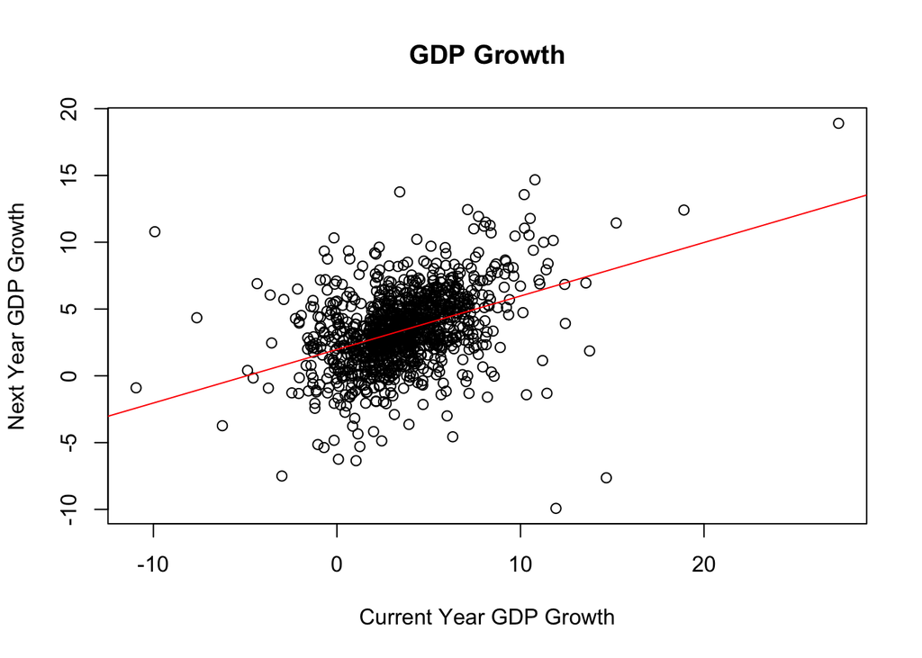

```r
plot(x=debt$growth,y=debt$next.growth,xlab = "Current Year GDP Growth",ylab = "Next Year GDP Growth",main ="GDP Growth")
abline(lm(next.growth~growth,data = debt),col="red")
```

```r
model_9<-lm(next.growth~growth,data = debt)
signif(model_9$coefficients,3)
```

```
## (Intercept)      growth
##       1.970       0.401
```

```r
summary(model_9)
```

```
##
## Call:
## lm(formula = next.growth ~ growth, data = debt)
##
## Residuals:
##     Min      1Q  Median      3Q     Max
## -16.674  -1.357   0.040   1.399  12.792
##
## Coefficients:
##             Estimate Std. Error t value Pr(>|t|)
## (Intercept)  1.97106    0.12040   16.37   <2e-16 ***
## growth       0.40065    0.02643   15.16   <2e-16 ***
## ---
## Signif. codes:  0 '***' 0.001 '**' 0.01 '*' 0.05 '.' 0.1 ' ' 1
##
## Residual standard error: 2.568 on 1145 degrees of freedom
##   (24 observations deleted due to missingness)
## Multiple R-squared:  0.1671, Adjusted R-squared:  0.1664
## F-statistic: 229.8 on 1 and 1145 DF,  p-value: < 2.2e-16
```

```r
#From graphs, model_8 has more points that deviate from the regression line than model_9, this indicated that model_9 is a better model.
#From stats, model_8 has a R square of 0.01771 which is significantly smaller than model_9's 0.1671, which also indicates that model_9 is a better performer.
#In conclusion, model_9 is better than model_9 in predicting the future growth, and current growth is a better indicator than debt ratio.
```